# Integrated Trend and Lagged Modeling of Multi-Subject, Multilevel, and Short Time Series: A Tutorial

Multilevel Growth with Autoregressive Residuals (ml-GAR)

Xiaoyue Xiong, Yanling Li, Michael D. Hunter & Sy-Miin Chow

2026-01-28

# 1 Introduction

This tutorial demonstrates the implementation of the **Multilevel Growth with Autoregressive Residuals (ml-GAR)** model, a Bayesian approach for simultaneously modeling trend and intraindividual variability in multi-subject, multilevel, and short time series data. This model is particularly useful for analyzing longitudinal panel data where both gradual developmental trends and momentary fluctuations occur.

## 1.1 Background and Motivation

Longitudinal data often contain two types of change processes:

1. **Trends (Intraindividual Change)**: Gradual, smoothly-varying functions of time that capture long-term variations in a time series.
2. **Intraindividual Variability**: Nuanced, usually reversible patterns of state fluctuations or short-term sequential dependencies whose effects diminish relatively quickly over time.

Failure to account for trends when they are present—or improper detrending due to misspecification of the functional forms of trend processes and associated interindividual differences—can introduce spurious sequential dependencies in the data. The ml-GAR model addresses this challenge by integrating trend and autoregressive (AR) modeling in a single-stage Bayesian framework.

## 1.2 Model Overview

The ml-GAR model integrates two key components:

1. **Multilevel Gompertz Growth Curve**: Captures gradual, nonlinear trend processes through person-specific asymptote ($\theta_{1,i}$), displacement ($\theta_{2,i}$), and growth rate ($\theta_{3,i}$) parameters.
2. **Multilevel Autoregressive (AR) Component**: Models temporal dependencies in the deviations from the trend, where the current observation depends on the previous deviation.

### 1.2.1 Mathematical Formulation

For person $i$ at time $t$, the observation model is (Equation 1 in the paper):

$$y_{t,i} = \tau_{t,i} + \eta_{t,i}$$

where $\tau_{t,i}$ represents the trend component and $\eta_{t,i}$ represents the state fluctuation component.

**Trend Component (Gompertz Growth Curve, Equation 2):**

$$\tau_{t,i} = \theta_{1,i} \exp\left[-\theta_{2,i} \exp(-t \cdot
\theta_{3,i})\right]$$

where:

- $\theta_{1,i}$: Asymptote parameter (upper limit of growth)
- $\theta_{2,i}$: Displacement parameter (horizontal shift)
- $\theta_{3,i}$: Growth rate parameter (steepness of the curve)

**State Fluctuation Component (AR Process):**

$$\eta_{t,i} = \phi_i \cdot \eta_{t-1,i} + u_{t,i}, \quad u_{t,i} \sim
N(0, \sigma^2_u)$$

where:

- $\phi_i$: Person-specific AR coefficient
- $u_{t,i}$: Process noise (innovation)

**Multilevel Structure:**

The person-specific parameters follow normal distributions:

$$\begin{aligned}
\theta_{k,i} &\sim N(\mu_{\theta_k}, \sigma^2_{\theta_k}), \quad k =
1, 2, 3 \\
\phi_i &\sim N(\mu_\phi, \sigma^2_\phi)
\end{aligned}$$

> **Note on notation**: In the accompanying code (and this tutorial), we use the following correspondences with the paper:
> - `MU[id,t]` corresponds to $\tau_{t,i}$ in the paper (Gompertz trend)
> - `MU_thetas[id,k]` corresponds to $\theta_{k,i}$ (person-specific Gompertz parameters)
> - `AR[id]` corresponds to $\phi_i$ (person-specific AR coefficient)
> - `Level2Mean_thetak` corresponds to $\mu_{\theta_k}$ (population mean)
> - `Level2Var_thetak` corresponds to $\sigma^2_{\theta_k}$ (random effect variance)
> - `Level2MeanAR` corresponds to $\mu_\phi$ (mean AR)
> - `Level2Var_AR` corresponds to $\sigma^2_\phi$ (variance of AR)
> - `IIV` corresponds to $\sigma^2_u$ (process noise variance)

# 2 Prerequisites

## 2.1 Required Packages

```r
# Load required packages
library(rjags)      # Interface to JAGS for Bayesian modeling
load.module("dic")  # Load DIC module for model comparison
library(coda)       # MCMC diagnostics and summaries
library(ggplot2)    # Visualization
library(MASS)       # For mvrnorm
```

## 2.2 Post-Processing Functions

The following functions are used for summarizing MCMC output. The `HDIofMCMC` function computes the Highest Density Interval (HDI), and `summarizePost` provides comprehensive summary statistics for all monitored parameters.

```r
#' Compute Highest Density Interval (HDI) from MCMC samples
#'
#' @param sampleVec A vector of MCMC samples
#' @param credMass Credible mass for the interval (default: 0.95)
#' @return A vector with HDI lower and upper bounds
HDIofMCMC <- function(sampleVec, credMass = 0.95) {
  sortedPts <- sort(sampleVec)
  ciIdxInc <- ceiling(credMass * length(sortedPts))
  nCIs <- length(sortedPts) - ciIdxInc
  ciWidth <- rep(0, nCIs)
  for (i in 1:nCIs) {
    ciWidth[i] <- sortedPts[i + ciIdxInc] - sortedPts[i]
  }
  HDImin <- sortedPts[which.min(ciWidth)]
  HDImax <- sortedPts[which.min(ciWidth) + ciIdxInc]
  HDIlim <- c(HDImin, HDImax)
  return(HDIlim)
}

#' Comprehensive MCMC Summary Statistics
#'
#' @param samples An mcmc.list object from coda.samples()
#' @param credMass Credible mass for HDI (default: 0.95)
#' @param CI Quantiles for credible intervals (default: c(.025, .975))
#' @return A data.frame with summary statistics for each parameter
summarizePost <- function(samples, credMass = 0.95, CI = c(.025, .975)) {

  # Ensure samples is a list
  if (!is.mcmc.list(samples)) {
    samples <- list(samples)
  } else {
    samples <- list(samples)
  }

  sampleCount <- length(samples)

  # Pre-calculate the number of expected rows
  rowCount <- 0
  for (k in 1:sampleCount) {
    rowCount <- rowCount + nvar(samples[[k]])
  }

  columnNames <- c()

  # Pre-allocate the result data frame
  result <- data.frame(
    mean = rep(NaN, rowCount),
    median = rep(NaN, rowCount),
    mode = rep(NaN, rowCount),
    PSD = rep(NaN, rowCount),
    hdiLow = rep(NaN, rowCount),
    hdiHigh = rep(NaN, rowCount),
    quantileLow = rep(NaN, rowCount),
    quantileHigh = rep(NaN, rowCount),
    SS = rep(NaN, rowCount),
    ESS = rep(NaN, rowCount),
    RHAT = rep(NaN, rowCount),
    stringsAsFactors = FALSE
  )

  currentRow <- 0

  # Process each model
  for (k in 1:sampleCount) {
    prefix <- ""
    if (sampleCount > 1) {
      prefix <- paste(k, ".", sep = "")
    }

    sample <- samples[[k]]
    variables <- nvar(sample)
    varnames_sample <- varnames(sample)
    iterations <- niter(sample)
    chains <- nchain(sample)

    for (j in 1:variables) {
      currentRow <- currentRow + 1

      uvalue <- unlist(sample[, j])
      value <- sample[, j]

      columnNames <- c(columnNames, paste(prefix, varnames_sample[[j]], sep = ""))

      result[currentRow, "SS"] <- iterations * chains
      result[currentRow, "ESS"] <- as.integer(round(effectiveSize(uvalue), 1))
      result[currentRow, "mean"] <- mean(uvalue)
      result[currentRow, "median"] <- median(uvalue)

      mcmcDensity <- density(uvalue)
      result[currentRow, "mode"] <- mcmcDensity$x[which.max(mcmcDensity$y)]

      HDI <- HDIofMCMC(uvalue, credMass)
      result[currentRow, "hdiLow"] <- HDI[1]
      result[currentRow, "hdiHigh"] <- HDI[2]

      resultCI <- quantile(uvalue, CI)
      result[currentRow, "quantileLow"] <- resultCI[1]
      result[currentRow, "quantileHigh"] <- resultCI[2]

      result[currentRow, "PSD"] <- sd(uvalue)

      # Gelman-Rubin RHAT calculation
      chainmeans <- c()
      chainvars <- c()
      for (i in 1:chains) {
        chain_sum <- sum(value[[i]])
        chain_var <- var(value[[i]])
        chain_mean <- chain_sum / iterations
        chainmeans <- c(chainmeans, chain_mean)
        chainvars <- c(chainvars, chain_var)
      }
      globalmean <- sum(chainmeans) / chains
      globalvar <- sum(chainvars) / chains

      # Between-chain variance
      b <- sum((chainmeans - globalmean)^2) * iterations / (chains - 1)

      # Marginal posterior variance
      varplus <- (iterations - 1) * globalvar / iterations + b / iterations

      # Gelman-Rubin statistic
      rhat <- sqrt(varplus / globalvar)

      if(is.na(rhat)) {
        rhat <- 1
      }

      result[currentRow, "RHAT"] <- rhat
    }
  }

  # Round results
  result <- data.frame(apply(result, 2, function(x) round(x, 4)))

  # Rename columns
  if (length(result) > 0) {
    names(result)[names(result) == 'hdiLow'] <- paste(sprintf("%.0f",
      round(credMass * 100, digits = 2)), "HDI_L", sep = "% ")
    names(result)[names(result) == 'hdiHigh'] <- paste(sprintf("%.0f",
      round(credMass * 100, digits = 2)), "HDI_H", sep = "% ")
    names(result)[names(result) == 'quantileLow'] <- paste("PCI",
      sprintf("%.1f%%", round(CI[1] * 100, digits = 3)), sep = " ")
    names(result)[names(result) == 'quantileHigh'] <- paste("PCI",
      sprintf("%.1f%%", round(CI[2] * 100, digits = 3)), sep = " ")
  }

  row.names(result) <- columnNames
  return(result)
}
```

# 3 Part 1: Data Generation

This section describes the data generation process for the ml-GAR model. The simulation generates multilevel longitudinal data with both Gompertz growth trends and AR dynamics, following the specifications in Xiong et al. (2025).

## 3.1 True Parameter Values

Based on the simulation study in the paper, we use the following true parameter values:

| Parameter | Symbol | True Value | Description |
| --- | --- | --- | --- |
| Asymptote mean | $\mu_{\theta_1}$ | 35 | Population mean of upper limit |
| Asymptote SD | $\sigma_{\theta_1}$ | 9 | SD of asymptote random effects |
| Displacement mean | $\mu_{\theta_2}$ | 4 | Population mean of horizontal shift |
| Displacement SD | $\sigma_{\theta_2}$ | 0.5 | SD of displacement random effects |
| Growth rate mean | $\mu_{\theta_3}$ | 0.8 | Population mean of growth rate |
| Growth rate SD | $\sigma_{\theta_3}$ | 0.1 | SD of growth rate random effects |
| AR mean | $\mu_\phi$ | 0.3 | Population mean of AR coefficient |
| AR variance | $\sigma^2_\phi$ | 0.01 | Variance of AR random effects |
| Process noise | $\sigma^2_u$ | 1 | Process noise variance (IIV) |

## 3.2 Data Generation Function

```r
#' Generate Simulated Data for ml-GAR Model
#'
#' @param nP Number of persons (default: 150)
#' @param nT Number of time points per person (default: 15)
#' @param seed Random seed for reproducibility
#' @return A list containing simulated data and true parameter values
generate_mlGAR_data <- function(nP = 150, nT = 15, seed = 123) {

  set.seed(seed)

  # ---- True Parameter Values (from Xiong et al., 2025) ----

  # Gompertz trend parameters (population means)
  theta10 <- 35        # Asymptote (upper limit)
  theta20 <- 4         # Displacement
  theta30 <- 0.8       # Growth rate

  # Gompertz trend parameters (random effect SDs)
  sigma1 <- 9          # SD of asymptote
  sigma2 <- 0.5        # SD of displacement
  sigma3 <- 0.1        # SD of growth rate

  # Correlation structure for Gompertz parameters (set to 0 for independent)
  r12 <- 0  # cor(theta_1, theta_2)
  r13 <- 0  # cor(theta_1, theta_3)
  r23 <- 0  # cor(theta_2, theta_3)

  # Covariance matrix for Gompertz parameters
  Q <- matrix(c(sigma1^2, r12*sigma1*sigma2, r13*sigma1*sigma3,
                r12*sigma1*sigma2, sigma2^2, r23*sigma2*sigma3,
                r13*sigma1*sigma3, r23*sigma2*sigma3, sigma3^2),
              byrow = TRUE, ncol = 3)

  # AR parameters
  AR_mean <- 0.3       # Population mean AR coefficient
  AR_var <- 0.01       # Variance of AR random effects
  AR_sd <- sqrt(AR_var)

  # Process noise variance (IIV)
  R <- 1               # Measurement/process noise variance

  # ---- Initialize Storage ----

  Y <- matrix(NA, nrow = nP, ncol = nT)          # Observed variable (y in paper)
  MU <- matrix(NA, nrow = nP, ncol = nT)         # Trend values (tau in paper)
  g <- matrix(NA, nrow = nP, ncol = nT)          # State fluctuations (eta in paper)

  theta1 <- rep(NA, nP)  # Person-specific asymptote
  theta2 <- rep(NA, nP)  # Person-specific displacement
  theta3 <- rep(NA, nP)  # Person-specific growth rate
  AR <- rep(NA, nP)      # Person-specific AR coefficients

  time <- 1:nT           # Time vector

  # ---- Simulate Data ----

  # Generate person-specific Gompertz parameters from multivariate normal
  theta_means <- c(theta10, theta20, theta30)
  thetas <- mvrnorm(n = nP, mu = theta_means, Sigma = Q)
  theta1 <- thetas[, 1]
  theta2 <- thetas[, 2]
  theta3 <- thetas[, 3]

  # Generate person-specific AR coefficients
  AR <- rnorm(nP, AR_mean, AR_sd)

  for (i in 1:nP) {
    # Generate Gompertz trend for all time points
    for (t in 1:nT) {
      MU[i, t] <- theta1[i] * exp(-theta2[i] * exp(-time[t] * theta3[i]))
    }

    # Generate state fluctuations (AR process)
    g[i, 1] <- rnorm(1, 0, sqrt(R))  # Initial state
    for (t in 2:nT) {
      g[i, t] <- AR[i] * g[i, t-1] + rnorm(1, 0, sqrt(R))
    }

    # Observed values = trend + state fluctuations
    Y[i, ] <- MU[i, ] + g[i, ]
  }

  # Create long-format data frame
  dat_long <- data.frame(
    id = rep(1:nP, each = nT),
    time = rep(time, nP),
    y1 = as.vector(t(Y))
  )

  # Return all simulated data and true parameters
  return(list(
    # Simulated data
    Y = Y,
    MU = MU,
    g = g,
    dat_long = dat_long,
    nP = nP,
    nT = nT,
    time = time,

    # True population parameters
    theta10 = theta10, sigma1 = sigma1,
    theta20 = theta20, sigma2 = sigma2,
    theta30 = theta30, sigma3 = sigma3,
    AR_mean = AR_mean, AR_var = AR_var,
    IIV = R,

    # Person-level parameters
    theta1 = theta1, theta2 = theta2, theta3 = theta3,
    AR = AR
  ))
}
```

## 3.3 Generate Sample Data

```r
# Generate sample data with N=150 persons and T=15 time points
# (matching simulation study conditions)
simdata <- generate_mlGAR_data(nP = 150, nT = 15, seed = 123)

# Display dimensions
cat("Data dimensions:\n")
```

```
## Data dimensions:
```

```r
cat("  Number of persons (N):", simdata$nP, "\n")
```

```
##   Number of persons (N): 150
```

```r
cat("  Number of time points (T):", simdata$nT, "\n")
```

```
##   Number of time points (T): 15
```

```r
cat("  Total observations:", nrow(simdata$dat_long), "\n")
```

```
##   Total observations: 2250
```

## 3.4 Visualize Simulated Data

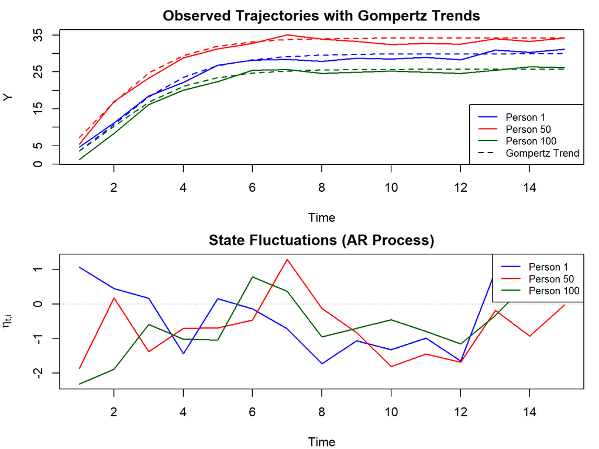

Sample trajectories from simulated data. Top: Observed trajectories (solid) with underlying Gompertz trends (dashed). Bottom: State fluctuations (deviations from trend).

```r
# Plot sample trajectories
par(mfrow = c(2, 1), mar = c(4, 4, 2, 1))

# Select a few persons to display
sample_ids <- c(1, 50, 100)
colors <- c("blue", "red", "darkgreen")

# Plot observed trajectories with trend
plot(simdata$time, simdata$Y[sample_ids[1], ], type = "l", col = colors[1],
     ylim = range(simdata$Y[sample_ids, ]), lwd = 1.5,
     xlab = "Time", ylab = "Y", main = "Observed Trajectories with Gompertz Trends")
lines(simdata$time, simdata$MU[sample_ids[1], ], col = colors[1], lty = 2, lwd = 1.5)

for (k in 2:length(sample_ids)) {
  lines(simdata$time, simdata$Y[sample_ids[k], ], col = colors[k], lwd = 1.5)
  lines(simdata$time, simdata$MU[sample_ids[k], ], col = colors[k], lty = 2, lwd = 1.5)
}

legend("bottomright",
       legend = c(paste("Person", sample_ids), "Gompertz Trend"),
       col = c(colors, "black"),
       lty = c(rep(1, length(sample_ids)), 2),
       lwd = 1.5, cex = 0.8)

# Plot state fluctuations
plot(simdata$time, simdata$g[sample_ids[1], ], type = "l", col = colors[1],
     ylim = range(simdata$g[sample_ids, ]), lwd = 1.5,
     xlab = "Time", ylab = expression(eta[t*","*i]),
     main = "State Fluctuations (AR Process)")
abline(h = 0, lty = 3, col = "gray")

for (k in 2:length(sample_ids)) {
  lines(simdata$time, simdata$g[sample_ids[k], ], col = colors[k], lwd = 1.5)
}

legend("topright",
       legend = paste("Person", sample_ids),
       col = colors, lty = 1, lwd = 1.5, cex = 0.8)
```

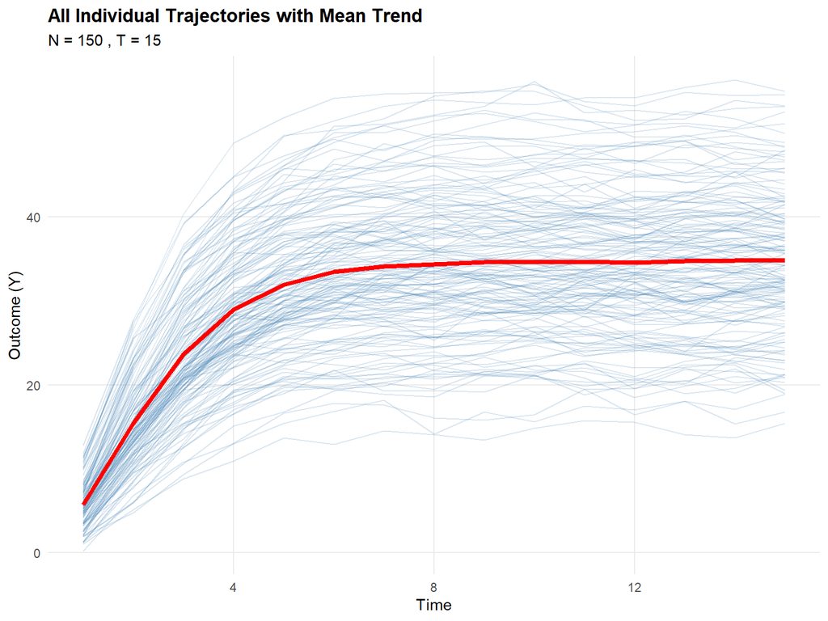

All individual trajectories showing the Gompertz growth pattern with individual variability.

```r
# Plot all trajectories using ggplot2
ggplot(simdata$dat_long, aes(x = time, y = y1, group = id)) +
  geom_line(alpha = 0.2, color = "steelblue") +
  stat_summary(aes(group = 1), fun = mean, geom = "line",
               color = "red", linewidth = 1.5) +
  labs(title = "All Individual Trajectories with Mean Trend",
       subtitle = paste("N =", simdata$nP, ", T =", simdata$nT),
       x = "Time", y = "Outcome (Y)") +
  theme_minimal() +
  theme(
    panel.grid.minor = element_blank(),
    plot.title = element_text(face = "bold")
  )
```

# 4 Part 2: Model Fitting with JAGS

## 4.1 JAGS Model Specification

The following sections walk through the JAGS model implementation of the ml-GAR framework step by step. We break the model into logical components and explain each part in detail.

### 4.1.1 Overview of the JAGS Model Structure

The JAGS model consists of several interconnected components:

| Component | Description | Key Parameters |
| --- | --- | --- |
| **Trend model** | Gompertz growth curve for each person | `MU[id,t]`, `MU_thetas[id,k]` |
| **AR dynamics** | Autoregressive process on deviations | `AR[id]` |
| **Level-2 model** | Random effects distributions | `Level2Mean_*`, `Level2Var_*` |
| **Priors** | Prior distributions for population parameters | Various hyperparameters |

### 4.1.2 Level-1 Model: Observation and Trend

The first code block handles the observation model for each person `id`. At each time point `t`:

- **Gompertz trend**: We compute the expected value based on the Gompertz growth function
- **AR dynamics**: The observation is modeled as the trend plus AR-dependent deviations

```
for (id in ids) { # opening loop for person (id)
  # model for the first point (t=1)
  Obs[1,2,id] ~ dnorm(MU[id,1], 1/IIV)
  MU[id,1] <- MU_thetas[id,1]*exp(-MU_thetas[id,2]*exp(-Obs[1,1,id]*MU_thetas[id,3]))

  # model for the rest (t=2 to T)
  for (t in 2:nT) { # opening loop for observation (t)
    Obs[t,2,id] ~ dnorm(MU[id,t] + AR[id]*(Obs[t-1,2,id]-MU[id,t-1]), 1/IIV)
    MU[id,t] <- MU_thetas[id,1]*exp(-MU_thetas[id,2]*exp(-Obs[t,1,id]*MU_thetas[id,3]))
  } # closing loop for observation (t)
```

**Key points about the observation model:**

- `MU[id,t]`: The Gompertz trend ($\tau_{t,i}$) for person `id` at time `t`, computed as $\theta_{1,i} \exp[-\theta_{2,i} \exp(-t \cdot \theta_{3,i})]$
- `AR[id]*(Obs[t-1,2,id]-MU[id,t-1])`: The AR component captures carry-over from the previous deviation ($\eta_{t-1,i}$)
- `1/IIV`: JAGS uses precision (inverse variance), so we specify `1/IIV` where `IIV` is the process noise variance ($\sigma^2_u$)

### 4.1.3 Level-2 Model: Person-Specific Parameters

The person-specific parameters are drawn from normal distributions centered at the population means. Note that the individual AR coefficients (`AR[id]`) are **not** truncatedâ€”only the population mean (`Level2MeanAR`) has the stationarity constraint:

```
# PART 2. Specifying Level-2 model
  AR[id] ~ dnorm(Level2MeanAR, 1/pow(Level2Sd_AR,2))
  MU_thetas[id,1] ~ dnorm(Level2Mean_theta1, 1/pow(Level2Sd_theta1,2))
  MU_thetas[id,2] ~ dnorm(Level2Mean_theta2, 1/pow(Level2Sd_theta2,2))
  MU_thetas[id,3] ~ dnorm(Level2Mean_theta3, 1/pow(Level2Sd_theta3,2))

} # closing loop for person (id)
```

**Understanding the Level-2 parameters:**

- `Level2MeanAR`: Population mean of AR coefficients ($\mu_\phi$)
- `Level2Sd_AR`: Standard deviation of AR random effects ($\sigma_\phi$)
- `Level2Mean_thetak`: Population mean of Gompertz parameter $k$ ($\mu_{\theta_k}$)
- `Level2Sd_thetak`: Standard deviation of Gompertz parameter $k$ ($\sigma_{\theta_k}$)

### 4.1.4 Prior Specifications

The priors section specifies our prior beliefs about the population-level parameters. We use weakly informative priors that provide reasonable bounds without imposing strong assumptions, following Table 3 in Xiong et al. (2025).

```
# PART 3. Specifying prior distributions

# AR parameters
Level2MeanAR ~ dnorm(0,1)T(-1,1)  # Truncated for stationarity
Level2Sd_AR ~ dunif(0,1)
Level2Var_AR = pow(Level2Sd_AR,2)

# Gompertz trend parameters
Level2Mean_theta1 ~ dunif(20, 50)     # Asymptote
Level2Mean_theta2 ~ dunif(0, 15)      # Displacement
Level2Mean_theta3 ~ dunif(0.5, 1.5)   # Growth rate

Level2Sd_theta1 ~ dunif(0.01, 15)     # SD of asymptote
Level2Sd_theta2 ~ dunif(0.01, 2)      # SD of displacement
Level2Sd_theta3 ~ dunif(0.01, 1)      # SD of growth rate

Level2Var_theta1 = pow(Level2Sd_theta1, 2)
Level2Var_theta2 = pow(Level2Sd_theta2, 2)
Level2Var_theta3 = pow(Level2Sd_theta3, 2)

# Process noise variance (IIV)
IIV <- exp(logIIV)
logIIV ~ dunif(-4.605170, 1.83)  # log(c(0.01, 6.25))
```

**Summary of prior specifications (Table 3 in paper):**

| Parameter | Prior Distribution | Rationale |
| --- | --- | --- |
| `Level2MeanAR` | $N(0,1)T(-1,1)$ | Truncated normal ensures stationarity |
| `Level2Sd_AR` | $U(0,1)$ | Weakly informative for SD |
| `Level2Mean_theta1` | $U(20,50)$ | Based on expected asymptote range |
| `Level2Mean_theta2` | $U(0,15)$ | Based on expected displacement |
| `Level2Mean_theta3` | $U(0.5,1.5)$ | Based on expected growth rate |
| `log(IIV)` | $U(\log(0.01), \log(6.25))$ | Log-scale for variance |

### 4.1.5 Complete JAGS Model Code

Now we combine all the components into a single model string:

```r
# Define JAGS model as a string (matching original code)
jags_model_string <- "
model {
# PART 1. Specifying Level-1 model
  for (id in ids) { # opening loop for person (id)
    # model for the first point (t=1)
    Obs[1,2,id] ~ dnorm(MU[id,1], 1/IIV)
    MU[id,1] <- MU_thetas[id,1]*exp(-MU_thetas[id,2]*exp(-Obs[1,1,id]*MU_thetas[id,3]))

    # model for the rest
    for (t in 2:nT) { # opening loop for observation (t)
      Obs[t,2,id] ~ dnorm(MU[id,t] + AR[id]*(Obs[t-1,2,id]-MU[id,t-1]), 1/IIV)
      MU[id,t] <- MU_thetas[id,1]*exp(-MU_thetas[id,2]*exp(-Obs[t,1,id]*MU_thetas[id,3]))
    } # closing loop for observation (t)

# PART 2. Specifying Level-2 model
  AR[id] ~ dnorm(Level2MeanAR, 1/pow(Level2Sd_AR,2))
  MU_thetas[id,1] ~ dnorm(Level2Mean_theta1, 1/pow(Level2Sd_theta1,2))
  MU_thetas[id,2] ~ dnorm(Level2Mean_theta2, 1/pow(Level2Sd_theta2,2))
  MU_thetas[id,3] ~ dnorm(Level2Mean_theta3, 1/pow(Level2Sd_theta3,2))

 } # closing loop for person (id)

# PART 3. Specifying prior distributions
  # AR
    Level2MeanAR ~ dnorm(0,1)T(-1,1)
    Level2Sd_AR ~ dunif(0,1)
    Level2Var_AR = pow(Level2Sd_AR,2)

  # Gompertz trend parameters (MU)
    Level2Mean_theta1 ~ dunif(20, 50)
    Level2Mean_theta2 ~ dunif(0, 15)
    Level2Mean_theta3 ~ dunif(0.5, 1.5)
    Level2Sd_theta1 ~ dunif(0.01, 15)
    Level2Sd_theta2 ~ dunif(0.01, 2)
    Level2Sd_theta3 ~ dunif(0.01, 1)
    Level2Var_theta1 = pow(Level2Sd_theta1, 2)
    Level2Var_theta2 = pow(Level2Sd_theta2, 2)
    Level2Var_theta3 = pow(Level2Sd_theta3, 2)

  # Process noise variance (IIV)
    IIV <- exp(logIIV)
    logIIV ~ dunif(-4.605170, 1.83)
}
"

# Write model to a temporary file
model_file <- tempfile(fileext = ".txt")
writeLines(jags_model_string, model_file)
cat("JAGS model saved to:", model_file, "\n")
```

```
## JAGS model saved to: C:\Users\xiong\AppData\Local\Temp\Rtmp0ooD5g\fileccf83b04ca0.txt
```

## 4.2 Prepare Data for JAGS

```r
# Convert data to array format for JAGS
# Obs array: [time, variable, person]
# variable 1 = time, variable 2 = outcome

nT <- simdata$nT
nP <- simdata$nP
ids <- 1:nP
ydim <- 1  # dimension of outcome variables

# Initialize observation array
Obs_empty <- rep(NA, nP * nT * (ydim + 1))
Obs <- array(Obs_empty, dim = c(nT, (ydim + 1), nP))

for (i in ids) {
  Obs[, 1, i] <- simdata$time        # Time variable
  Obs[, 2, i] <- simdata$Y[i, ]      # Outcome variable
}

# Check data for id=1
cat("Data for id=1 (columns = time, y1):\n")
```

```
## Data for id=1 (columns = time, y1):
```

```r
print(Obs[, , 1])
```

```
##       [,1]      [,2]
##  [1,]    1  4.667219
##  [2,]    2 11.212287
##  [3,]    3 18.443746
##  [4,]    4 22.158299
##  [5,]    5 26.850669
##  [6,]    6 28.193563
##  [7,]    7 28.442951
##  [8,]    8 27.839444
##  [9,]    9 28.702490
## [10,]   10 28.543897
## [11,]   11 28.929590
## [12,]   12 28.281771
## [13,]   13 30.900848
## [14,]   14 30.358044
## [15,]   15 31.208716
```

```r
# Prepare data list for JAGS
jagsData <- list(
  Obs = Obs,
  ids = ids,
  nT = nT
)

# Display data structure
cat("\nJAGS data structure:\n")
```

```
##
## JAGS data structure:
```

```r
cat("  Obs array dimensions:", dim(Obs), "(time x variables x persons)\n")
```

```
##   Obs array dimensions: 15 2 150 (time x variables x persons)
```

```r
cat("  Number of persons:", length(ids), "\n")
```

```
##   Number of persons: 150
```

```r
cat("  Number of time points:", nT, "\n")
```

```
##   Number of time points: 15
```

## 4.3 MCMC Settings

The following settings match those used in the simulation study (Xiong et al., 2025):

```r
# Level-2 parameters to summarize
summ_rownames <- c("IIV", "Level2MeanAR", "Level2Var_AR",
                   "Level2Mean_theta1", "Level2Var_theta1",
                   "Level2Mean_theta2", "Level2Var_theta2",
                   "Level2Mean_theta3", "Level2Var_theta3")

# Parameters to track
parameters <- c("AR", "MU", "MU_thetas", summ_rownames)

# MCMC settings (based on Xiong et al., 2025 paper description)
adaptation <- 5000     # Adaptation iterations
burnin <- 10000        # Burn-in iterations
chains <- 2            # Number of MCMC chains
thinning <- 2          # Thinning interval (paper uses 2)
nrOfIter <- 10000      # Number of iterations for posterior sampling

# Fixed initial values for reproducibility
fixedinits <- list(
  list(.RNG.seed = 6, .RNG.name = "base::Mersenne-Twister"),
  list(.RNG.seed = 11, .RNG.name = "base::Mersenne-Twister")
)

cat("MCMC Settings (based on Xiong et al., 2025):\n")
```

```
## MCMC Settings (based on Xiong et al., 2025):
```

```r
cat("  Chains:", chains, "\n")
```

```
##   Chains: 2
```

```r
cat("  Adaptation:", adaptation, "\n")
```

```
##   Adaptation: 5000
```

```r
cat("  Burn-in:", burnin, "\n")
```

```
##   Burn-in: 10000
```

```r
cat("  Sampling iterations:", nrOfIter, "\n")
```

```
##   Sampling iterations: 10000
```

```r
cat("  Thinning:", thinning, "\n")
```

```
##   Thinning: 2
```

```r
cat("  Posterior samples per chain:", nrOfIter / thinning, "\n")
```

```
##   Posterior samples per chain: 5000
```

## 4.4 Run JAGS Model

```r
# Track computation time
main_t_start <- proc.time()

# Initialize JAGS model
cat("Initializing JAGS model...\n")
jagsModel <- jags.model(
  file = model_file,
  data = jagsData,
  n.chains = chains,
  n.adapt = adaptation,
  inits = fixedinits
)

# Burn-in
cat("Running burn-in (", burnin, " iterations)...\n", sep = "")
update(jagsModel, n.iter = burnin)

# Sample from posterior
cat("Sampling from posterior (", nrOfIter, " iterations, thin = ", thinning, ")...\n", sep = "")
codaSamples <- coda.samples(
  jagsModel,
  variable.names = parameters,
  n.iter = nrOfIter,
  thin = thinning
)

main_t_end <- proc.time()
main_t_elapsed <- main_t_end - main_t_start
cat("MCMC sampling complete!\n")
cat("Total computation time:", round(main_t_elapsed[3], 2), "seconds\n")
```

[output not shown]

# 5 Part 3: Results and Diagnostics

## 5.1 Parameter Estimates

```r
# Generate summary statistics
resulttable <- summarizePost(codaSamples)

# Display results for population-level parameters
cat("\n=== Population Parameter Estimates ===\n\n")
```

```
##
## === Population Parameter Estimates ===
```

```r
print(resulttable[summ_rownames, c("mean", "PSD", "95% HDI_L", "95% HDI_H", "ESS", "RHAT")])
```

```
##                      mean    PSD 95% HDI_L 95% HDI_H  ESS   RHAT
## IIV                0.9563 0.0343    0.8928    1.0256 2384 1.0000
## Level2MeanAR       0.2802 0.0302    0.2190    0.3353  497 1.0026
## Level2Var_AR       0.0111 0.0103    0.0000    0.0311  114 1.0034
## Level2Mean_theta1 34.7642 0.7132   33.3214   36.1062 9016 1.0001
## Level2Var_theta1  73.9993 8.6985   59.0257   92.6913 9247 1.0000
## Level2Mean_theta2  4.0747 0.0648    3.9452    4.2001 1537 1.0003
## Level2Var_theta2   0.2956 0.0655    0.1781    0.4287 1005 1.0019
## Level2Mean_theta3  0.7990 0.0102    0.7790    0.8186 2476 1.0004
## Level2Var_theta3   0.0109 0.0016    0.0080    0.0143 3147 1.0006
```

## 5.2 Compare Estimates to True Values

```r
# Create comparison table
true_values <- c(
  IIV = simdata$IIV,
  Level2MeanAR = simdata$AR_mean,
  Level2Var_AR = simdata$AR_var,
  Level2Mean_theta1 = simdata$theta10,
  Level2Var_theta1 = simdata$sigma1^2,
  Level2Mean_theta2 = simdata$theta20,
  Level2Var_theta2 = simdata$sigma2^2,
  Level2Mean_theta3 = simdata$theta30,
  Level2Var_theta3 = simdata$sigma3^2
)

comparison <- data.frame(
  Parameter = names(true_values),
  True = true_values,
  Estimate = resulttable[names(true_values), "mean"],
  PSD = resulttable[names(true_values), "PSD"],
  HDI_Low = resulttable[names(true_values), "95% HDI_L"],
  HDI_High = resulttable[names(true_values), "95% HDI_H"],
  row.names = NULL
)

comparison$Bias <- comparison$Estimate - comparison$True
comparison$rBias <- comparison$Bias / comparison$True
comparison$Coverage <- ifelse(comparison$True >= comparison$HDI_Low &
                               comparison$True <= comparison$HDI_High,
                             "Yes", "No")

cat("\n=== Comparison with True Values ===\n\n")
```

```
##
## === Comparison with True Values ===
```

```r
print(comparison, digits = 3)
```

```
##           Parameter  True Estimate    PSD HDI_Low HDI_High    Bias    rBias
## 1               IIV  1.00   0.9563 0.0343   0.893   1.0256 -0.0437 -0.04370
## 2      Level2MeanAR  0.30   0.2802 0.0302   0.219   0.3353 -0.0198 -0.06600
## 3      Level2Var_AR  0.01   0.0111 0.0103   0.000   0.0311  0.0011  0.11000
## 4 Level2Mean_theta1 35.00  34.7642 0.7132  33.321  36.1062 -0.2358 -0.00674
## 5  Level2Var_theta1 81.00  73.9993 8.6985  59.026  92.6913 -7.0007 -0.08643
## 6 Level2Mean_theta2  4.00   4.0747 0.0648   3.945   4.2001  0.0747  0.01867
## 7  Level2Var_theta2  0.25   0.2956 0.0655   0.178   0.4287  0.0456  0.18240
## 8 Level2Mean_theta3  0.80   0.7990 0.0102   0.779   0.8186 -0.0010 -0.00125
## 9  Level2Var_theta3  0.01   0.0109 0.0016   0.008   0.0143  0.0009  0.09000
##   Coverage
## 1      Yes
## 2      Yes
## 3      Yes
## 4      Yes
## 5      Yes
## 6      Yes
## 7      Yes
## 8      Yes
## 9      Yes
```

## 5.3 Convergence Diagnostics

### 5.3.1 RHAT and ESS Summary

```r
# Check convergence via RHAT and ESS for Level-2 parameters
convergence_table <- data.frame(
  Parameter = summ_rownames,
  ESS = resulttable[summ_rownames, "ESS"],
  RHAT = resulttable[summ_rownames, "RHAT"]
)

cat("\n=== Convergence Summary (Level-2 Parameters) ===\n\n")
```

```
##
## === Convergence Summary (Level-2 Parameters) ===
```

```r
print(convergence_table, row.names = FALSE)
```

```
##          Parameter  ESS   RHAT
##                IIV 2384 1.0000
##       Level2MeanAR  497 1.0026
##       Level2Var_AR  114 1.0034
##  Level2Mean_theta1 9016 1.0001
##   Level2Var_theta1 9247 1.0000
##  Level2Mean_theta2 1537 1.0003
##   Level2Var_theta2 1005 1.0019
##  Level2Mean_theta3 2476 1.0004
##   Level2Var_theta3 3147 1.0006
```

```r
max_rhat <- max(convergence_table$RHAT, na.rm = TRUE)
min_ess <- min(convergence_table$ESS, na.rm = TRUE)

cat("\nMaximum RHAT:", round(max_rhat, 4), "\n")
```

```
##
## Maximum RHAT: 1.0034
```

```r
cat("Minimum ESS:", min_ess, "\n")
```

```
## Minimum ESS: 114
```

```r
if (max_rhat < 1.1 & min_ess >= 250) {
  cat("Conclusion: All chains appear to have converged (RHAT < 1.1, ESS >= 250).\n")
} else {
  cat("Note: Consider increasing iterations for more reliable inference.\n")
}
```

```
## Note: Consider increasing iterations for more reliable inference.
```

### 5.3.2 Trace Plots

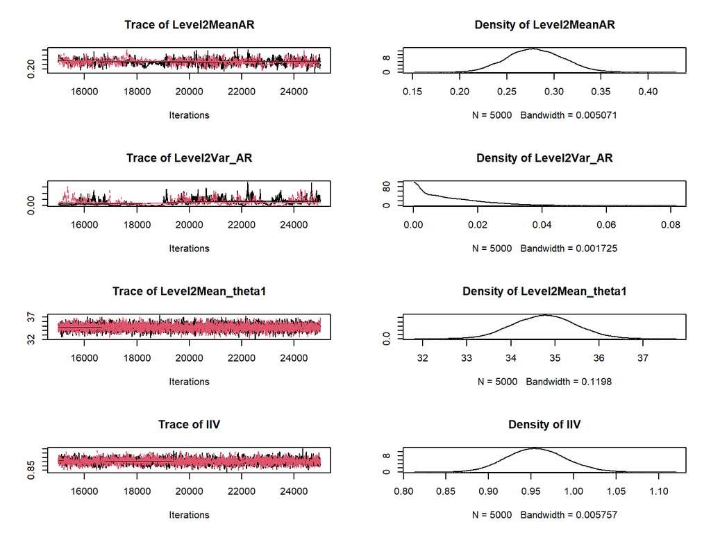

Trace plots and density plots for key population parameters.

```r
# Select key parameters for visualization
key_params <- c("Level2MeanAR", "Level2Var_AR", "Level2Mean_theta1", "IIV")

# Check if parameters exist in samples
available_params <- key_params[key_params %in% varnames(codaSamples)]

if (length(available_params) > 0) {
  # Extract samples for key parameters
  samples_subset <- codaSamples[, available_params]

  # Plot trace and density
  plot(samples_subset)
}
```

## 5.4 Visualize Parameter Recovery

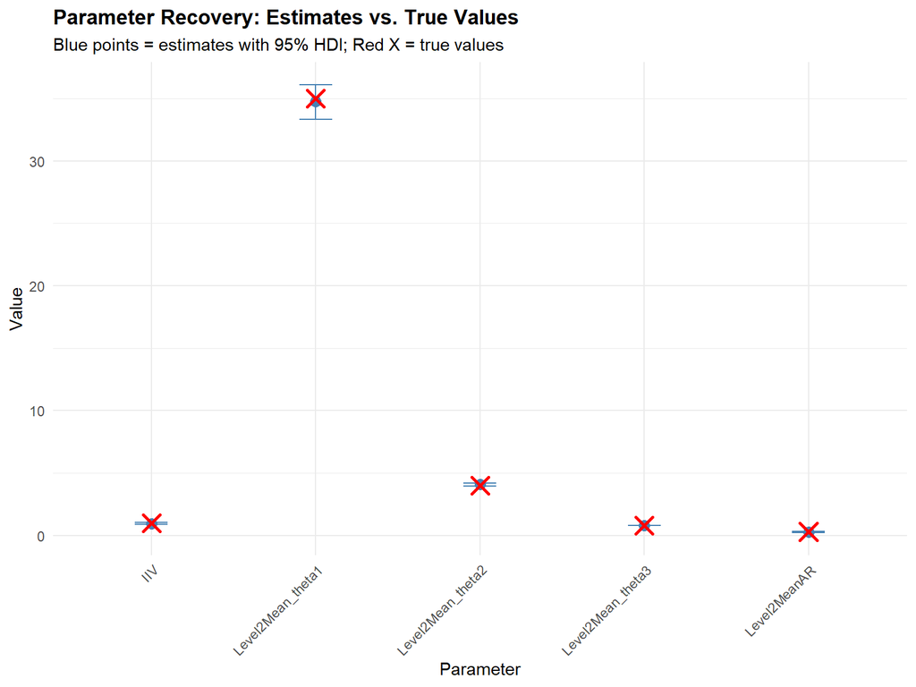

Parameter recovery: Estimated values (points with 95% HDIs) compared to true values (red X marks).

```r
# Create visualization of parameter recovery for means only
comparison_means <- comparison[!grepl("Var", comparison$Parameter), ]

if (nrow(comparison_means) > 0) {
  ggplot(comparison_means, aes(x = Parameter, y = Estimate)) +
    geom_point(size = 3, color = "steelblue") +
    geom_errorbar(aes(ymin = HDI_Low, ymax = HDI_High),
                  width = 0.2, color = "steelblue") +
    geom_point(aes(y = True), shape = 4, size = 4, color = "red", stroke = 1.5) +
    labs(title = "Parameter Recovery: Estimates vs. True Values",
         subtitle = "Blue points = estimates with 95% HDI; Red X = true values",
         x = "Parameter", y = "Value") +
    theme_minimal() +
    theme(
      axis.text.x = element_text(angle = 45, hjust = 1),
      plot.title = element_text(face = "bold")
    )
}
```

# 6 Summary

This tutorial demonstrated:

1. **Model Conceptualization**: The ml-GAR model integrates Gompertz growth trends with multilevel AR dynamics to simultaneously capture gradual developmental changes and momentary state fluctuations.
2. **Data Generation**: How to simulate data from the ml-GAR model with parameters matching Xiong et al. (2025):
   - Gompertz parameters: $\mu_{\theta_1} = 35$, $\mu_{\theta_2} = 4$, $\mu_{\theta_3} = 0.8$
   - Random effect SDs: $\sigma_{\theta_1} = 9$, $\sigma_{\theta_2} = 0.5$, $\sigma_{\theta_3} = 0.1$
   - AR dynamics: $\mu_\phi = 0.3$, $\sigma^2_\phi = 0.01$
   - Process noise: $\sigma^2_u = 1$
3. **Model Specification**: The JAGS model syntax implementing the hierarchical structure with:
   - Level-1: Observation model with Gompertz trend and AR dynamics
   - Level-2: Random effects for person-specific parameters (AR not truncated at individual level)
   - Priors: Weakly informative priors as specified in Table 3 of the paper
4. **Model Fitting**: Using `rjags` with settings based on the paper:
   - Adaptation: 5000 iterations
   - Burn-in: 10^{4} iterations
   - Sampling: 10^{4} iterations per chain
   - Chains: 2
   - Thinning: 2 (yielding 5000 samples per chain)
5. **Post-Analysis**: Comprehensive diagnostics including:
   - Parameter estimates with posterior SDs and HDIs
   - Comparison with true values (bias, relative bias, coverage)
   - Convergence diagnostics (ESS, RHAT)

# 8 References

- Asparouhov, T., & Muthén, B. (2010). Bayesian analysis using Mplus: Technical implementation. Muthén & Muthén.
- Gates, K. M., Chow, S.-M., & Molenaar, P. C. M. (2023). *Intensive longitudinal analysis of human processes*. Chapman and Hall/CRC.
- Ji, L., Chow, S.-M., Schermerhorn, A. C., Jacobson, N. C., & Cummings, E. M. (2020). Handling missing data in the modeling of intensive longitudinal data. *Structural Equation Modeling: A Multidisciplinary Journal*, 27(5), 715â€“736.
- Li, Y., Oravecz, Z., Zhou, S., Bodber, Y., & Chow, S.-M. (2022). Bayesian forecasting with a regime-switching zero-inflated multilevel Poisson regression model: An application to adolescent alcohol use with selective missingness. *Psychometrika*, 87(3), 978â€“1008.
- Plummer, M. (2003). JAGS: A program for analysis of Bayesian graphical models using Gibbs sampling. In *Proceedings of the 3rd International Workshop on Distributed Statistical Computing*.
- Xiong, X., Li, Y., Hunter, M. D., & Chow, S.-M. (2025). Integrated trend and lagged modeling of multi-subject, multilevel, and short time series. *Multivariate Behavioral Research*. https://doi.org/10.1080/00273171.2025.2587286